# Descripción

La segmentación de clientes es un proceso a través del cual se clasifica a los mismos en diferentes grupos que comparten características similares de formas tales que los resultados sean relevantes para acciones específicas, como por ejemplo campañas de marketing. Las características utilizadas para describir a cada cliente pueden ser edad, sexo, intereses, hábitos de consumo, entre otros.

# Dataset

Para este proyecto, se provee de un conjunto de datos con las siguientes características:

- Origen: Exposys Data Labs
- Columnas:
  - CustomerID: identificador único del cliente
  - Gender: género del cliente
  - Age: edad del cliente
  - Annual Income (k$): ingresos anuales del cliente
  - Spending Score (1-100): puntaje relacionado al nivel de gastos del cliente

# Consigna

Los objetivos principales del proyecto son dos:

- identificar la base de clientes con mayor potencial para la venta de producto/s
- implementar algoritmos de clustering para segmentar la base de clientes

```python
import numpy as np
import matplotlib.pyplot as plt
import seaborn as sns
import pandas as pd
from sklearn.cluster import KMeans, DBSCAN
from sklearn.metrics import silhouette_samples, silhouette_score
from IPython.display import display_html
import plotly.graph_objects as go
from plotly.subplots import make_subplots
from plotly.offline import init_notebook_mode
init_notebook_mode(connected=True)
import plotly.express as px
from utils import (quantile_target_distribution_plot_relative,
                   quantile_target_distribution_relative)
```

Carga dataset

```python
df = pd.read_csv('Mall_Customers.csv')
df.head()
```

|  | CustomerID | Gender | Age | Annual Income (k$) | Spending Score (1-100) |
| --- | --- | --- | --- | --- | --- |
| 0 | 1 | Male | 19 | 15 | 39 |
| 1 | 2 | Male | 21 | 15 | 81 |
| 2 | 3 | Female | 20 | 16 | 6 |
| 3 | 4 | Female | 23 | 16 | 77 |
| 4 | 5 | Female | 31 | 17 | 40 |

# Análisis exploratorio de datos

```python
# Tipo de datos de las columnas
df.dtypes
```

```
CustomerID                 int64
Gender                    object
Age                        int64
Annual Income (k$)         int64
Spending Score (1-100)     int64
dtype: object
```

```python
# Tamaño del dataset
df.shape
```

```
(200, 5)
```

```python
# Chequeo de nulos por columnas
for col in df.columns:
    print(f'{col}: has {sum(df[col].isnull())} nulls')
```

```
CustomerID: has 0 nulls
Gender: has 0 nulls
Age: has 0 nulls
Annual Income (k$): has 0 nulls
Spending Score (1-100): has 0 nulls
```

|  | Gender |
| --- | --- |
| count | 200 |
| unique | 2 |
| top | Female |
| freq | 112 |

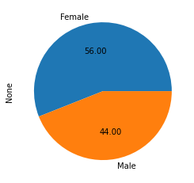

```python
# Estadíasticas de las columnas salvo el customerID.
display_html(df.describe(include = 'object'))
df.groupby('Gender').size().plot(kind='pie', autopct='%.2f')
```

Hay más mujeres que hombres en el dataset

|  | Age | Annual Income (k$) | Spending Score (1-100) |
| --- | --- | --- | --- |
| count | 200.000000 | 200.000000 | 200.000000 |
| mean | 38.850000 | 60.560000 | 50.200000 |
| std | 13.969007 | 26.264721 | 25.823522 |
| min | 18.000000 | 15.000000 | 1.000000 |
| 25% | 28.750000 | 41.500000 | 34.750000 |
| 50% | 36.000000 | 61.500000 | 50.000000 |
| 75% | 49.000000 | 78.000000 | 73.000000 |
| max | 70.000000 | 137.000000 | 99.000000 |

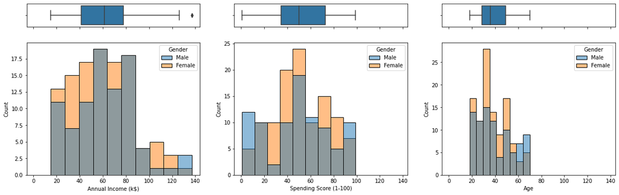

```python
display_html(df.iloc[:,1::].describe())
print()


# creating a figure composed of two matplotlib.Axes objects (ax_box and ax_hist)
f, axs = plt.subplots(2, 3, sharex=True, gridspec_kw={"height_ratios": (.15, .85)}, figsize=(20,6))

# assigning a graph to each ax
sns.boxplot(x=df['Annual Income (k$)'], ax=axs[0,0])
sns.histplot(data=df, x=df['Annual Income (k$)'], hue='Gender', ax=axs[1,0])


sns.boxplot(x=df['Spending Score (1-100)'], ax=axs[0,1])
sns.histplot(data=df, x=df['Spending Score (1-100)'], hue='Gender', ax=axs[1,1])

sns.boxplot(x=df['Age'], ax=axs[0,2])
sns.histplot(data=df, x=df['Age'], hue='Gender', ax=axs[1,2])

# Remove x axis name for the boxplot
axs[0,0].set(xlabel='')
axs[0,1].set(xlabel='')
axs[0,2].set(xlabel='')
plt.show()
```

Como lineamiento general para la segmentación:

- No se utilizará el género y la edad para evitar introducir sesgos,
- No se utilizará el id de cliente ya que es un identificador único y no aporta valor a la segmentación de cliente.
- Lo anterior reduce el espacio de variables para la segmentación a: *ingresos anuales* y *score de gastos*

A continuación se realiza un análisis bivariado de datos

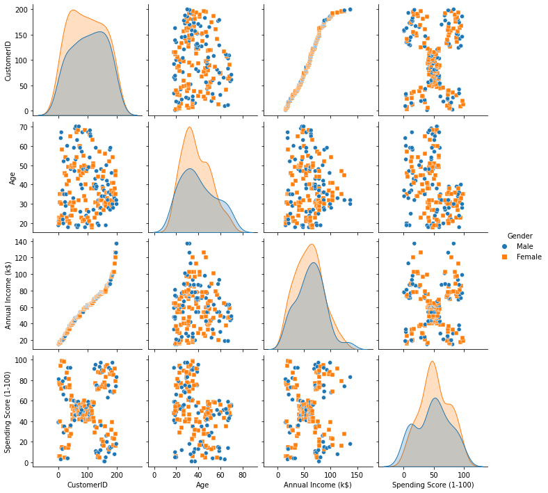

```python
sns.pairplot(data=df, hue="Gender", markers=["o", "s"])
```

```python
df_original = df.copy()
```

## Mapeo de variable categórica *Gender*

Se convierte la variable catergórica *Gender* a numérica para poder utilizar posteriormente KMeans.

```python
gender_mapper = {'Female': 0, 'Male': 1}
df['Gender'] = df['Gender'].map(gender_mapper)
```

## Eliminación de la variable CustomerID

```python
df.drop(columns='CustomerID', inplace=True)
```

## Matriz de correlación

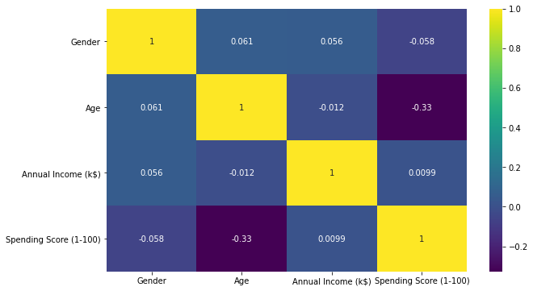

```python
plt.figure(figsize=(10,6))
#matrix = np.triu(corr)
#sns.heatmap(df.corr(), annot=True, mask=matrix, cmap='viridis')
sns.heatmap(df.corr(), annot=True, cmap='viridis')
```

- La edad está inversamente correlacionada con el score de gasto.
- El ingreso anual está muy poco correlacionado con la edad
- el ingreso anual y el score de gasto también están poco correlacionados
- el género está muy poco correlacionado con el score de gasto pero más correlacionado cuando se lo compara con el ingreso anual.

## Tratamiento de outliers

Los outliers se evalúan a través del método de rango intercuartílico.

```
DataFrame size before outlier treatment: (200, 4)
DataFrame size after outlier treatment: (198, 4)
```

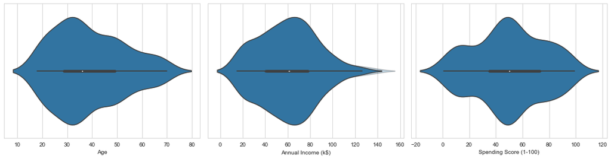

```python
from utils import treat_outiers

sns.set_style("whitegrid")
cols = ['Age', 'Annual Income (k$)','Spending Score (1-100)']
fig, axes = plt.subplots(nrows=1, ncols=len(cols), figsize=(15,4))

print('DataFrame size before outlier treatment: {0}'.format(df.shape))

ir = 0
outliers = []
for col in cols:
    ax = sns.violinplot(x=col, data=df, ax=axes[ir], label= col + ' --> outliers')
    plt.setp(ax.collections, alpha=.3)


    df, outlier_indexes = treat_outiers(df, col)
    # Si existen outliers, se agregan a una lista para luego utilizarse.
    if len(outlier_indexes) > 1:
        outliers.append(outlier_indexes)

    sns.violinplot(x=col, data=df, ax=axes[ir], label=col + ' --> without outliers')
    ir += 1

fig.tight_layout()

print('DataFrame size after outlier treatment: {0}'.format(df.shape))
```

Existen 2 outliers en el ingreso anual.

```python
# Características de los outliers detectados
df_original.loc[outliers[0], ['Gender', 'Age', 'Annual Income (k$)', 'Spending Score (1-100)']]
```

|  | Gender | Age | Annual Income (k$) | Spending Score (1-100) |
| --- | --- | --- | --- | --- |
| 198 | Male | 32 | 137 | 18 |
| 199 | Male | 30 | 137 | 83 |

## Escalado de variables

El escalado de variables se habilita/deshabilita con un flag (bool).  
Por defecto, se comienza sin escalar y luego se evalúa el impacto del escalado en los resultados (esto implica tener ejecutar las celdas desde aquí en adelante debiendo modificar los valores de los hiperparámetros)

```python
from sklearn.preprocessing import StandardScaler

scale_vars = False

if scale_vars:
    scaler = StandardScaler()
    columns = ['Age', 'Annual Income (k$)','Spending Score (1-100)']
    for col in columns:
        df[col] = scaler.fit_transform(df[[col]])
```

# Clustering no supervisado

- No se utilizará el género y la edad para evitar introducir sesgos,
- No se utilizará el id de cliente ya que es un identificador único y no aporta valor a la segmentación de cliente.
- Lo anterior reduce el espacio de variables para la segmentación a: *ingresos anuales* y *score de gastos*

```python
X1 = df[['Spending Score (1-100)', 'Annual Income (k$)']]
```

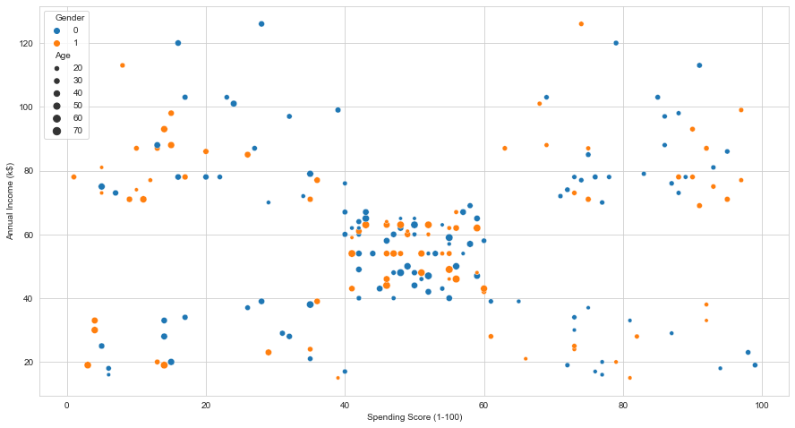

```python
plt.figure(figsize=(15,8))
sns.scatterplot(x=df['Spending Score (1-100)'],
                y=df['Annual Income (k$)'],
                data=df,
                hue="Gender",
                size="Age",
                sizes=(np.min(df.Age), np.max(df.Age)))
plt.show()
```

Por simple inspección, la segmentación parecería poder hacerse en 5 grupos; de todas maneras veremos que nos dice el método del codo.

## Kmeans

Método del codo

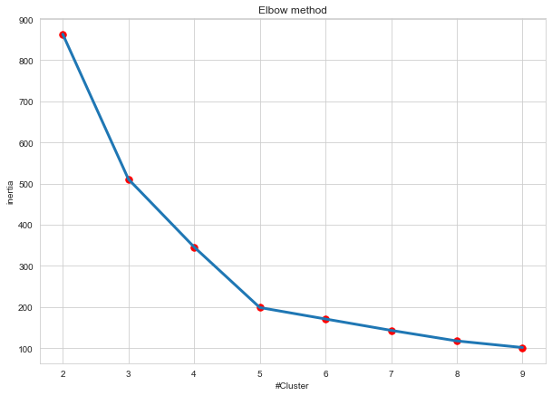

```python
# Preparamos una lista donde vamos a ir agregando las distancias medias
Sum_of_squared_distances = []
# Fiteammos un modelo para cada numero de cluster que queremos testear
K = np.arange(2,10)
for k in K:
    # Definimos y entrenamos el modelo
    km = KMeans(n_clusters=k)
    km = km.fit(X1)
    # Calculamos la distancia media y agregamos a la lista
    distancia_total = km.inertia_
    distancia_media = np.divide(distancia_total,X1.shape[0])
    Sum_of_squared_distances.append(distancia_media)

plt.figure(figsize = (10,7))
plt.plot(K, Sum_of_squared_distances, lw=3)
plt.scatter(K, Sum_of_squared_distances,s=55,c='r')
plt.xlabel('#Cluster')
plt.ylabel('inertia')
plt.title('Elbow method')
plt.show()
```

Efectivamente el método del codo no muestra que el a partir de 5 clusters, la inercia decae.  
Veamos que dice el método de silueta.

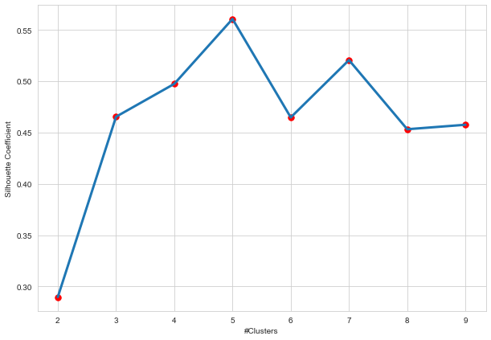

```python
silhouette_coefficients = []

for k in K:
    kmeans = KMeans(n_clusters=k)
    kmeans.fit(X1)
    score = silhouette_score(X1, kmeans.labels_)
    silhouette_coefficients.append(score)

plt.figure(figsize = (10,7))
plt.plot(K, silhouette_coefficients, lw=3)
plt.scatter(K, silhouette_coefficients, s=55,c='r')
plt.xticks(K)
plt.xlabel("#Clusters")
plt.ylabel("Silhouette Coefficient")
plt.show()
```

Siluetas

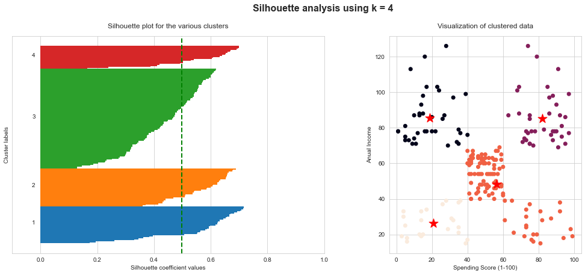

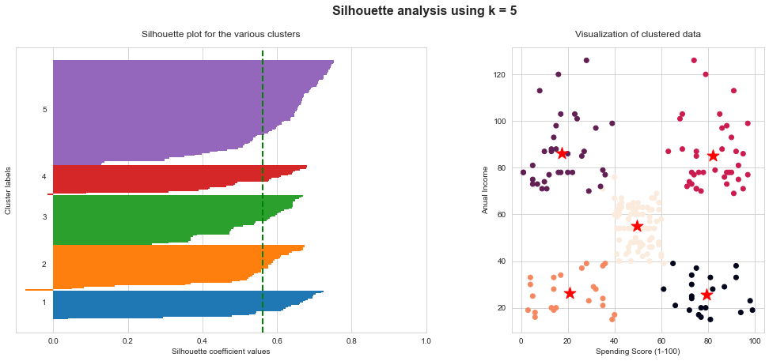

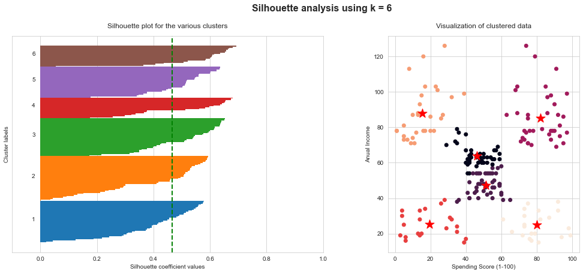

```python
# Aca ponen el Dataset con el que quieren trabajar
X_std = X1
# Aca definen la lista de ks para los cuales quieren hacer un gráfico
k_list = [4, 5, 6]

for i, k in enumerate(k_list):
    fig, (ax1, ax2) = plt.subplots(1, 2, figsize=(15,6))

    # Run the Kmeans algorithm
    km = KMeans(n_clusters=k)
    labels = km.fit_predict(X_std)
    centroids = km.cluster_centers_

    # Get silhouette samples
    silhouette_vals = silhouette_samples(X_std, labels)

    # Silhouette plot
    y_ticks = []
    y_lower, y_upper = 0, 0
    for i, cluster in enumerate(np.unique(labels)):
        cluster_silhouette_vals = silhouette_vals[labels == cluster]
        cluster_silhouette_vals.sort()
        y_upper += len(cluster_silhouette_vals)
        ax1.barh(range(y_lower, y_upper), cluster_silhouette_vals, edgecolor='none', height=1)
        ax1.text(-0.03, (y_lower + y_upper) / 2, str(i + 1))
        y_lower += len(cluster_silhouette_vals)

    # Get the average silhouette score and plot it
    avg_score = np.mean(silhouette_vals)
    ax1.axvline(avg_score, linestyle='--', linewidth=2, color='green')
    ax1.set_yticks([])
    ax1.set_xlim([-0.1, 1])
    ax1.set_xlabel('Silhouette coefficient values')
    ax1.set_ylabel('Cluster labels')
    ax1.set_title('Silhouette plot for the various clusters', y=1.02);

    # Scatter plot of data colored with labels
    ax2.scatter(X_std.iloc[:, 0], X_std.iloc[:, 1], c=labels)
    ax2.scatter(centroids[:, 0], centroids[:, 1], marker='*', c='r', s=250)
    ax2.set_xlabel('Spending Score (1-100)')
    ax2.set_ylabel('Anual Income')
    ax2.set_title('Visualization of clustered data', y=1.02)
    ax2.set_aspect('equal')
    plt.tight_layout()
    plt.suptitle(f'Silhouette analysis using k = {k}',
                 fontsize=16, fontweight='semibold', y=1.05);
```

Acorde al método del codo y el score de silueta, 5 cluster parecería ser la mejor representación.  
Eventualmente (hipótesis) se podría pensar en utilizar una configuración con 6 clusters que permita generar un insight más detallado en clientes con ingresos anuales y puntajes de gasto intermedios. La información disponible en el dataset se considera insuficiente para abordar tal configuración; por lo tanto, **por defecto se asume una configuración con 5 clusters**.

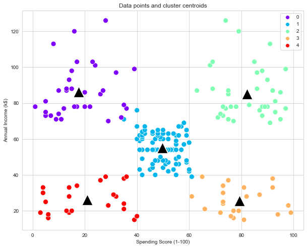

```python
from sklearn.cluster import KMeans
kmeans = KMeans(n_clusters=5, random_state=0)
kmeans.fit(X1)

labels_kmeans = kmeans.labels_
centroids = kmeans.cluster_centers_

plt.figure(figsize=(10,8))
sns.scatterplot(x=X1['Spending Score (1-100)'],
                y=X1['Annual Income (k$)'],
                s=100 ,
                hue = labels_kmeans,
                palette="rainbow")
sns.scatterplot(x=centroids[:, 0],
                y=centroids[:, 1],
                color='black',
                marker="^",
                s=500)
plt.title('Data points and cluster centroids')
plt.show()
```

De éste último gráfico podemos ver que los clientes pueden ser agrupados en al menos 5 grupos distintos basados en su ingreso anual y su score de gastos.

- **Rojo:** Bajo ingreso anual, bajo puntaje de gasto.
- **Violeta:** Alto ingreso anual, bajo puntaje de gasto.
- **Azul:** ingreso anual intermedio, puntaje de gasto intermedio
- **Verde:** Alto ingreso anual, alto puntaje de gasto.
- **Naranja:** bajo ingreso anual, alto puntaje de gasto.

Se agregan los labels de cada cluster obtenidos con la clusterización al DataFrame original para poder generar un gráfico de proporciones

```python
df['kmeans_labels'] = np.zeros((df.shape[0])).astype(int)
for k in range(kmeans.n_clusters):
    ix = np.where(kmeans.labels_ == k)[0]
    df.loc[ix, 'kmeans_labels'] = k

df.head()
```

|  | Gender | Age | Annual Income (k$) | Spending Score (1-100) | kmeans_labels |
| --- | --- | --- | --- | --- | --- |
| 0 | 1 | 19 | 15 | 39 | 4 |
| 1 | 1 | 21 | 15 | 81 | 3 |
| 2 | 0 | 20 | 16 | 6 | 4 |
| 3 | 0 | 23 | 16 | 77 | 3 |
| 4 | 0 | 31 | 17 | 40 | 4 |

Se asignan los outliers detectados a los grupos definidos por KMeans y el dataset limpio

```python
x = df_original.loc[outliers[0], ['Spending Score (1-100)', 'Annual Income (k$)']]
outliers_kmeans_labels = kmeans.predict(x)
```

```python
# DataFrame Outliers
df_outliers = df_original.loc[outliers[0], ['Gender', 'Age', 'Spending Score (1-100)', 'Annual Income (k$)']]
display_html(df_outliers)
# Se convierte la variable categórica Género a numérica
df_outliers['Gender'] = df_outliers['Gender'].map(gender_mapper)
# Se asignan los outliers a los cluster armados
df_outliers['kmeans_labels']= outliers_kmeans_labels
display_html(df_outliers)
# Se agregan los outliers clasificados al dataset
df = pd.concat([df, df_outliers])
```

|  | Gender | Age | Spending Score (1-100) | Annual Income (k$) |
| --- | --- | --- | --- | --- |
| 198 | Male | 32 | 18 | 137 |
| 199 | Male | 30 | 83 | 137 |

|  | Gender | Age | Spending Score (1-100) | Annual Income (k$) | kmeans_labels |
| --- | --- | --- | --- | --- | --- |
| 198 | 1 | 32 | 18 | 137 | 0 |
| 199 | 1 | 30 | 83 | 137 | 2 |

```python
df.shape
```

```
(200, 5)
```

# Descripción de clusters

Al negocio le interesa una descripción más cualitativa que cuantitativa de los clusters. En otras palabras, para el negocio lo ideal sería poder brindar una descripción general de los cluster acompañado con algunos números. Esto, generalmente, se hace a través de una interpretación de variables subyacentes.  
Pueden existir variables que no aportan a la descripción del cluster; eso es importante destacarlo también.

Se vuelve a mapear el género para poder tener una idea de cómo está distribuido el género en los clusters.

```python
df_kmeans = df.copy()
gender_mapper = {0: 'Female', 1: 'Male'}
df_kmeans['Gender'] = df_kmeans['Gender'].map(gender_mapper)
df_kmeans.tail()
```

|  | Gender | Age | Annual Income (k$) | Spending Score (1-100) | kmeans_labels |
| --- | --- | --- | --- | --- | --- |
| 195 | Female | 35 | 120 | 79 | 2 |
| 196 | Female | 45 | 126 | 28 | 0 |
| 197 | Male | 32 | 126 | 74 | 2 |
| 198 | Male | 32 | 137 | 18 | 0 |
| 199 | Male | 30 | 137 | 83 | 2 |

Veamos como se distribuye, en porcentajes, el género en cada clsuter.

```python
pd.set_option('precision', 2)
pd.DataFrame(df_kmeans.groupby(['kmeans_labels'])['Gender'].value_counts(normalize=True))
```

| kmeans_labels | Gender | Gender |
| --- | --- | --- |
| 0 | Male | 0.53 |
|  | Female | 0.47 |
| 1 | Female | 0.59 |
|  | Male | 0.41 |
| 2 | Female | 0.54 |
|  | Male | 0.46 |
| 3 | Female | 0.59 |
|  | Male | 0.41 |
| 4 | Female | 0.61 |
|  | Male | 0.39 |

- cluster 0, mayormente hombres
- cluster 1, mayormente mujeres
- cluster 2, mayormente mujeres
- cluster 3, mayormente mujeres
- cluster 4, mayormente mujeres

| kmeans_labels | Age | Annual Income (k$) | Spending Score (1-100) |
| --- | --- | --- | --- |
| 0 | 41 | 88 | 18 |
| 1 | 43 | 55 | 50 |
| 2 | 33 | 87 | 82 |
| 3 | 25 | 26 | 79 |
| 4 | 45 | 26 | 21 |

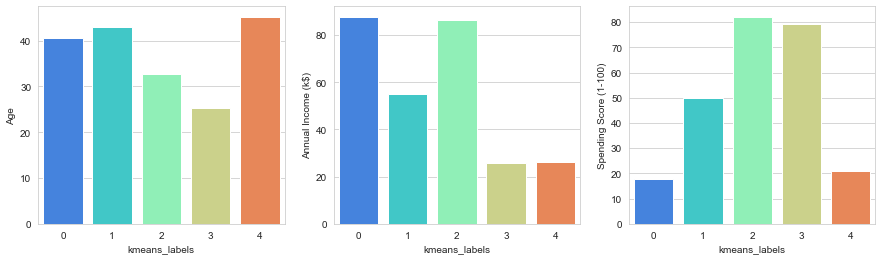

```python
pd.set_option('precision', 0)
# Agrupo por label de cluster
#stats = df_kmeans.groupby(['kmeans_labels'], as_index=False).describe()
avg_data = df_kmeans.groupby(['kmeans_labels'], as_index=False).mean()
std_data = df_kmeans.groupby(['kmeans_labels'], as_index=False).std()
display_html(avg_data.style.hide_index())
# display_html(std_data.style.hide_index())


fig, axs = plt.subplots(1, 3, figsize=(15,4))
sns.barplot(x='kmeans_labels',y='Age',palette="rainbow",data=avg_data, ax=axs[0])
sns.barplot(x='kmeans_labels',y='Annual Income (k$)',palette="rainbow",data=avg_data, ax=axs[1])
sns.barplot(x='kmeans_labels',y='Spending Score (1-100)',palette="rainbow",data=avg_data, ax=axs[2])
plt.show()
```

- cluster 0: Edad promedio 41 años; predominantemente hombres; ingreso anual promedio 88k dolares; puntaje de gasto promedio 18
- cluster 1: Edad promedio 43 años; predominantemente mujeres; ingreso anual promedio 55k dolares; puntaje de gasto promedio 50
- cluster 2: Edad promedio 33 años; predominantemente mujeres; ingreso anual promedio 87k dolares; puntaje de gasto promedio 82
- cluster 3: Edad promedio 25 años; predominantemente mujeres; ingreso anual promedio 26k dolares; puntaje de gasto promedio 79
- cluster 4: Edad promedio 45 años; predominantemente mujeres; ingreso anual promedio 26k dolares; puntaje de gasto promedio 21

### Cluster 0: Gastadores cautelosos

Este grupo está formado por personas de mediana edad que son cuidadosos en cuanto a sus hábitos de gasto.

Aunque los niveles de ingresos son altos, gastan muy poco. Este podría ser un indicador de sus responsabilidades financieras.

Sugerencia: las tarjetas de membresía, los cupones de descuento, las ofertas, etc. podrían tener un impacto en este grupo.

### Cluster 1: Clientes de clase media

Este grupo está formado por clientes de mediana edad que gastan y ganan dinero en un nivel intermedio.

Tienen cuidado con su escala de gastos ya que sus niveles de ingresos no son excesivos.

Estas personas también pueden ser las que tengan mayores responsabilidades financieras. Por ejemplo, la educación superior de sus hijos.

Sugerencia: ofertas de descuentos, códigos promocionales, tarjetas de fidelización, etc.

### Cluster 2: Clientes con buen pasar económico

Este segmento está formado por personas de mediana edad que acumularon una cantidad significativa de riqueza en sus años iniciales.

También tienen una gran escala de gastos y, por lo tanto, llevan un estilo de vida muy próspero.

Sugerencia: La mayoría de las personas de este grupo de edad podrían estar en la fase inicial de formar una familia. Por lo tanto, es más probable que la promoción de bienes raíces, propiedades, ofertas de automóviles, etc. capte su atención. Se presume que estas personas contraen serios compromisos financieros con todos los clusters debido a su alta capacidad de gasto.

### Cluster 3: Compradores compulsivos/impulsivos/irracionales

Este segmento está formado por jóvenes descuidados con sus hábitos de gasto.

Es probable que este grupo esté compuesto por primeros trabajadores que tienden a gastar por encima de sus posibilidades en la búsqueda de un buen estilo de vida.

Sugerencias: Dado que a muchos jóvenes les encanta la idea de vacacionar, proporcionar a este segmento los cupones de hotel adecuados, las ofertas de vuelos pueden ser una buena idea. También se considera que este grupo gasta el máximo en ropa y accesorios relacionados en comparación con otros grupos. Ofrecer descuentos adecuados para dichos productos también podría ser una estrategia útil.

### Cluster 4: Inactivos/Pensionados

Este segmento está formado por la población mayor que gana y gasta menos. Puede que estén ahorrando para la jubilación.

Sugerencias: Los productos relacionados con la salud se pueden promover entre este grupo. El uso de cupones de descuento adecuados, códigos de promoción, etc. también puede ayudar.

## Gráficos de proporciones

Éstos gráficos nos dan las distribuciones porcentuales.  
Cada color corresponde a un cluster y los gráficos porcentuales se realizan sobre variables que no se utilizaron en la clusterización y pasan a ser variables descriptivas.  
¿Cuando una variable puede explicar la distribución por cluster? Cuando su proporción/distribución por cluster varía.  
Lo interesante de este tipo de gráficos es que permite visualizar por simple inspección (de manera visual) si una variable es descriptiva o no.

```python
labels_mapper = {0: 'Cautious spenders',
                 1: 'Middle-class customer',
                 2: 'Top customers',
                 3: 'Impetuous buyers',
                 4: 'Innactive customers'}
df_kmeans['kmeans_labels'] = df_kmeans['kmeans_labels'].map(labels_mapper)
```

```python
df_kmeans.tail()
```

|  | Gender | Age | Annual Income (k$) | Spending Score (1-100) | kmeans_labels |
| --- | --- | --- | --- | --- | --- |
| 195 | Female | 35 | 120 | 79 | Top customers |
| 196 | Female | 45 | 126 | 28 | Cautious spenders |
| 197 | Male | 32 | 126 | 74 | Top customers |
| 198 | Male | 32 | 137 | 18 | Cautious spenders |
| 199 | Male | 30 | 137 | 83 | Top customers |

```python
df_aux = pd.DataFrame()
# Se podrían tomar más columnas!
desire_columns = df.columns[0:-1]
print(desire_columns)
for col in desire_columns:
    f = quantile_target_distribution_relative(df_kmeans, col, 15, target='kmeans_labels')
    f['col'] = col
    df_aux = pd.concat([df_aux, f])


fig = px.bar(df_aux,
             x ='INTERVAL',
             y='PROPORTION',
             color='kmeans_labels',
             barmode='relative',
             height=1000,
             facet_row='col')
fig.update_layout(title_text='Numerical features')
fig.update_xaxes(matches=None)
fig.update_yaxes(range=[0,1])
fig.show()
```

```
Index(['Gender', 'Age', 'Annual Income (k$)', 'Spending Score (1-100)'], dtype='object')
```

[interactive chart not shown]

Veamos a qué cluster han sido asignados los outliers detectados.

```python
df_kmeans.loc[outliers[0], :]
```

|  | Gender | Age | Annual Income (k$) | Spending Score (1-100) | kmeans_labels |
| --- | --- | --- | --- | --- | --- |
| 198 | Male | 32 | 137 | 18 | Cautious spenders |
| 199 | Male | 30 | 137 | 83 | Top customers |

## DBSCAN

Lo primero que se debe determinar es cuál es el **eps** y el **min_samples**.  
Epsilon define la máxima distancia entre dos puntos para que estos sean considerados del mismo grupo.

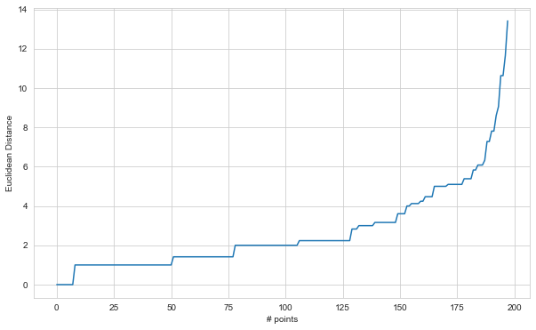

```python
from sklearn.neighbors import NearestNeighbors
plt.figure(figsize=(10, 6))
neigh = NearestNeighbors(n_neighbors=k)
nbrs = neigh.fit(X1)
distances, indices = nbrs.kneighbors(X1)
distances = np.sort(distances, axis=0)
distances = distances[:,1]
plt.plot(distances)
plt.xlabel('# points')
plt.ylabel('Euclidean Distance')
plt.show()
```

Se hace un barrido sobre una grilla de *eps* y _min*samples* para ver cuál es la mejor configuración de hiperparámetros para DBSCAN.

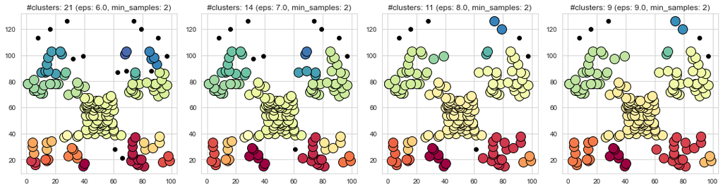

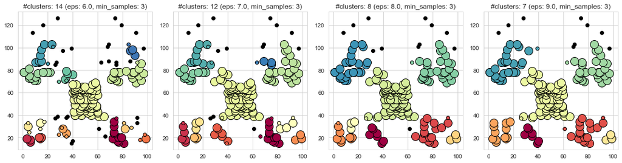

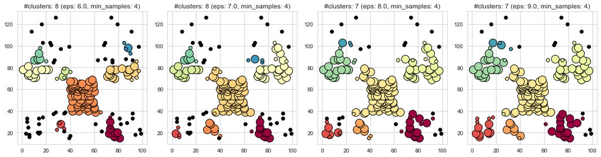

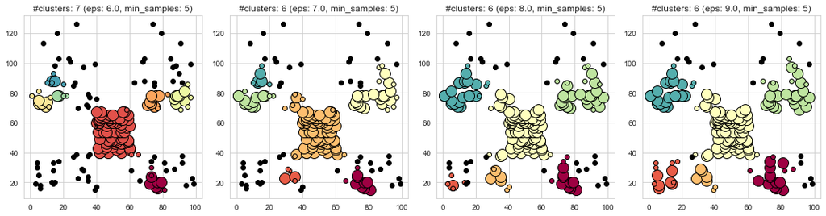

```python
# En este paso tenemos que definir el epsilon y en min_samples, los parametros del método.
from sklearn.cluster import DBSCAN
from utils import plot_DBSCAN

X = np.zeros((X1.shape[0], X1.shape[1]))
X[:, 0] = X1['Spending Score (1-100)']
X[:, 1] = X1['Annual Income (k$)']

eps_grid = np.arange(6, 10, 1)
min_samples_grid = np.arange(2, 6, 1)


for min_samples_val in min_samples_grid:
    fig, axes = plt.subplots(nrows=1, ncols=len(eps_grid), figsize=(15,4))
    col_ix = row_ix = 0
    print()
    for eps_val in eps_grid:
        db = DBSCAN(eps=eps_val, min_samples=min_samples_val)
        db.fit(X1)

        # Consultamos las etiquetas
        labels = db.labels_

        # Number of clusters in labels, ignoring noise if present.
        n_clusters = len(set(labels)) - (1 if -1 in labels else 0)
        n_noise = list(labels).count(-1)

        #print('(#clusters, #noise points): {:d} - {:d}'.format(n_clusters,n_noise))

        plot_DBSCAN(X,labels,db,n_clusters, axes[col_ix])
        col_ix += 1

    fig.tight_layout()
    plt.show()
```

Como se puede observar, no hay una configuración de DBSCAN que permita obtener resultados similares a KMeans. Esto se debe fundamentalmente a la geometría del los datos utilizados para la clusterización.  
Bajo la premisa de que el desempeño de DBSCAN sea similar al obtenido con KMeans, la configuración adoptada para DBSCAN es: **eps=9** y **min_samples=3*.

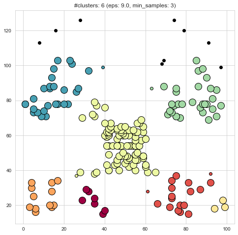

```python
db = DBSCAN(eps=9, min_samples=3)
db.fit(X1)
n_clusters = len(set(labels)) - (1 if -1 in labels else 0)

fig, ax = plt.subplots(nrows=1, ncols=1, figsize=(8,8))
plot_DBSCAN(X,db.labels_,db,n_clusters, ax)
```

Se asignan las etiquetas del clustering con DBSCAN

```python
df['DBSCAN_labels'] = np.zeros((df.shape[0])).astype(int)
for k in range(n_clusters):
    ix = np.where(db.labels_ == k)[0]
    df.loc[ix, 'DBSCAN_labels'] = k

df.head()
```

|  | Gender | Age | Annual Income (k$) | Spending Score (1-100) | kmeans_labels | DBSCAN_labels |
| --- | --- | --- | --- | --- | --- | --- |
| 0 | 1 | 19 | 15 | 39 | 4 | 0 |
| 1 | 1 | 21 | 15 | 81 | 3 | 1 |
| 2 | 0 | 20 | 16 | 6 | 4 | 2 |
| 3 | 0 | 23 | 16 | 77 | 3 | 1 |
| 4 | 0 | 31 | 17 | 40 | 4 | 0 |

## Clustering jerárquico

Se comienza el clustering jerarquico evaluando la totalidad de los niveles.

```python
from sklearn.cluster import AgglomerativeClustering
model = AgglomerativeClustering(distance_threshold=0, n_clusters=None)
model = model.fit(X1)
```

```python
from scipy.cluster.hierarchy import dendrogram
from scipy.cluster import hierarchy
Z = hierarchy.linkage(model.children_, 'ward')
```

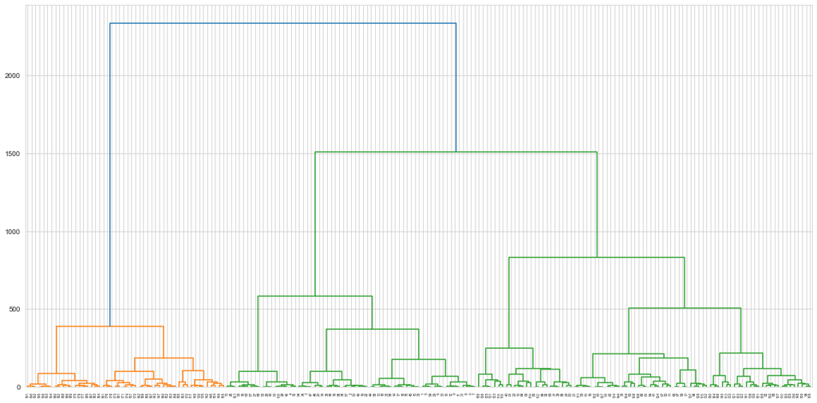

```python
plt.figure(figsize=(20,10))
dn = hierarchy.dendrogram(Z)
```

La base del dendograma corresponde a los puntos individuales.  
Las líneas horizontales simplemente muestran la unión de los clusters.  
La longitud de las líneas verticales representa el recorrido que hizo el algoritmo para lograr unirlo con algo. Por lo tanto, si la longitud de las líneas verticales es "larga", significa que el punto está lejos de los demas como para formar un cluster; mientras que si la línea vertical es "corta", el punto está cerca de otros.  
A trevés del dendograma (de las longitudes verticales) podríamos determinar qué punto podría ser un potencial outlier. Si cortamos con una línea horizontal a diferentes niveles vamos a poder seleccionar diferentes estadíos de la formación del clustering jerárquico y quedarnos con una configuración que consideremos adecuada (apuntamos a obtener el mismo resultado que KMeans.

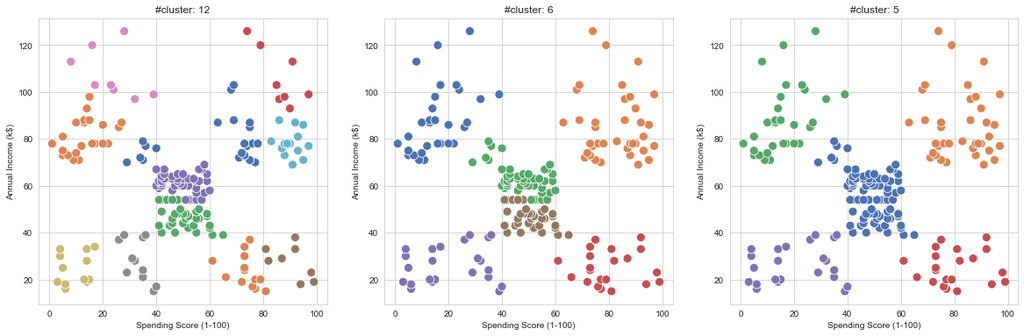

```python
n_cluster = [12, 6, 5]
fig, axes = plt.subplots(nrows=1, ncols=len(n_cluster), figsize=(20,6))
ix = 0
for k in n_cluster:
    aggloclust = AgglomerativeClustering(n_clusters=k).fit(X1)

    sns.scatterplot(x=X1['Spending Score (1-100)'],
                    y=X1['Annual Income (k$)'],
                    s=100,
                    hue = aggloclust.labels_,
                    palette="deep",
                    ax=axes[ix],
                    legend=False)

    axes[ix].set_title("#cluster: " + str(aggloclust.n_clusters_))
    ix += 1

plt.show()
```

Se toman 5 clusters para tener un punto de comparación con KMeans

```python
aggloclust = AgglomerativeClustering(n_clusters=5)
aggloclust = aggloclust.fit(X1)
aggloclust.n_clusters_
```

```
5
```

Se agregan las etiquetas del clustering aglomerativo al dataframe.

```python
df['agglomerative_labels'] = np.zeros((df.shape[0])).astype(int)
for k in range(aggloclust.n_clusters_):
    ix = np.where(aggloclust.labels_ == k)[0]
    df.loc[ix, 'agglomerative_labels'] = k

df.head()
```

|  | Gender | Age | Annual Income (k$) | Spending Score (1-100) | kmeans_labels | DBSCAN_labels | agglomerative_labels |
| --- | --- | --- | --- | --- | --- | --- | --- |
| 0 | 1 | 19 | 15 | 39 | 4 | 0 | 4 |
| 1 | 1 | 21 | 15 | 81 | 3 | 1 | 3 |
| 2 | 0 | 20 | 16 | 6 | 4 | 2 | 4 |
| 3 | 0 | 23 | 16 | 77 | 3 | 1 | 3 |
| 4 | 0 | 31 | 17 | 40 | 4 | 0 | 4 |

Representación de los clusters obtenidos con clustering jerárquico y 5 clusters.

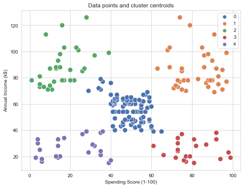

```python
plt.figure(figsize=(8,6))

sns.scatterplot(x=X1['Spending Score (1-100)'],
                y=X1['Annual Income (k$)'],
                s=100,
                hue = aggloclust.labels_,
                palette="deep")
plt.title('Data points and cluster centroids')
plt.show()
```

# Reducción de dimensionalidad

Evaluamos si vale la pena aplicar reducción de dimensionalidad.  
En lo desarrollado hasta aquí hemos utilizado dos variables. Con esto presente, para que la aplicación de PCA valga la pena deberíamos encontrar un espacio unidimensional que explique casi el total de la varianza. A priori, parece poco probable. De todas maneras, evualamos PCA.

```python
# Contruimos un DataFrame que únicamente tenga los datos del DataSet orginal.
df_pca = df.iloc[:,:-3].copy()
display_html(df_pca)
```

|  | Gender | Age | Annual Income (k$) | Spending Score (1-100) |
| --- | --- | --- | --- | --- |
| 0 | 1 | 19 | 15 | 39 |
| 1 | 1 | 21 | 15 | 81 |
| 2 | 0 | 20 | 16 | 6 |
| 3 | 0 | 23 | 16 | 77 |
| 4 | 0 | 31 | 17 | 40 |
| ... | ... | ... | ... | ... |
| 195 | 0 | 35 | 120 | 79 |
| 196 | 0 | 45 | 126 | 28 |
| 197 | 1 | 32 | 126 | 74 |
| 198 | 1 | 32 | 137 | 18 |
| 199 | 1 | 30 | 137 | 83 |

200 rows × 4 columns

Instanciamos PCA sin hiperparámetros para ver las componentes principales y poder determinar qué variables son las que concetran la mayor información.

```python
from sklearn.decomposition import PCA
pca = PCA()
components = pca.fit_transform(df_pca)
```

```python
import plotly.express as px

labels = {
    str(i): f"PC {i+1} ({var:.1f}%)"
    for i, var in enumerate(pca.explained_variance_ratio_ * 100)
}

fig = px.scatter_matrix(
    components,
    labels=labels,
    dimensions=range(df_pca.shape[1])
)
fig.update_traces(diagonal_visible=False)
fig.show()
```

[interactive chart not shown]

Notar que 2 componentes principales explican el 89.2% de la varianza.

Se utiliza PCA con 2 componentes (respecto de lo que veníamos trabajando estaríamos teniendo una transformación de variables en un espacio proyectado)

```python
# Escalamos variables
#scaler = StandardScaler()
#X1 = scaler.fit_transform(X1)
```

```python
pca = PCA(n_components=2)
principal_components = pca.fit_transform(X1)
```

Se instancia KMeans con **n_cluster=5** con el objetivo de poder comparar los resultados entre kmeans con y sin reducción de dimensionalidad.

```python
kmeans_pca = KMeans(n_clusters=5, random_state=0)
kmeans_pca.fit(principal_components)
```

```
KMeans(n_clusters=5, random_state=0)
```

Se representan los clusters obtenidos con PCA

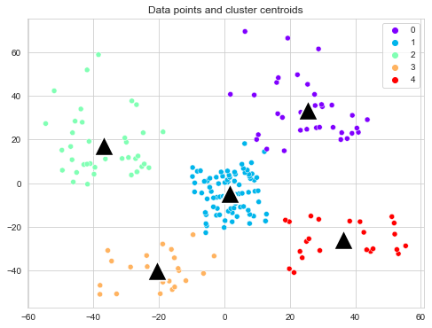

```python
plt.figure(figsize=(8,6))
sns.scatterplot(x=principal_components[:, 0],
                y=principal_components[:, 1],
                hue = kmeans_pca.labels_,
                palette='rainbow')
sns.scatterplot(x=kmeans_pca.cluster_centers_[:, 0],
                y=kmeans_pca.cluster_centers_[:, 1],
                color='black',
                marker="^", s=500)
plt.title('Data points and cluster centroids')
plt.show()
```

```python
labels = {
    str(i): f"PC {i+1} ({var:.1f}%)"
    for i, var in enumerate(pca.explained_variance_ratio_ * 100)
}

fig = px.scatter_matrix(
    principal_components,
    labels=labels,
    dimensions=range(2)
)
fig.update_traces(diagonal_visible=False)
fig.show()
```

[interactive chart not shown]

Se agregan las etiquetas de kmeans_pca al *DataFrame* final

```python
df['kmeans_pca_labels'] = np.zeros((df.shape[0])).astype(int)
for k in range(kmeans_pca.n_clusters):
    ix = np.where(kmeans_pca.labels_ == k)[0]
    df.loc[ix, 'kmeans_pca_labels'] = k

df.head()
```

|  | Gender | Age | Annual Income (k$) | Spending Score (1-100) | kmeans_labels | DBSCAN_labels | agglomerative_labels | kmeans_pca_labels |
| --- | --- | --- | --- | --- | --- | --- | --- | --- |
| 0 | 1 | 19 | 15 | 39 | 4 | 0 | 4 | 4 |
| 1 | 1 | 21 | 15 | 81 | 3 | 1 | 3 | 3 |
| 2 | 0 | 20 | 16 | 6 | 4 | 2 | 4 | 4 |
| 3 | 0 | 23 | 16 | 77 | 3 | 1 | 3 | 3 |
| 4 | 0 | 31 | 17 | 40 | 4 | 0 | 4 | 4 |

# Comparación de etiquetas entre métodos

## KMeans y KMeans con PCA

```python
pd.set_option('precision', 2)
error = df.kmeans_labels - df.kmeans_pca_labels
error.describe()
```

```
count    200.00
mean       0.01
std        0.14
min        0.00
25%        0.00
50%        0.00
75%        0.00
max        2.00
dtype: float64
```

## KMeans y Clustering jerárquico

```python
error = df.kmeans_labels - df.agglomerative_labels
error.describe()
```

```
count    200.00
mean       0.30
std        1.09
min       -2.00
25%        0.00
50%        1.00
75%        1.00
max        3.00
dtype: float64
```

# Conclusiones

La descripción de los clusters se resume a continuación

| ID | Denominación | Características | Descripción | Segerencia Negocios |  |
| --- | --- | --- | --- | --- | --- |
| 0 | Cautelosos | Edad promedio 41 años. Predominantemente hombres. Ingreso anual promedio 88k dolares. Puntaje de gasto promedio 18. | Este grupo está formado por personas de mediana edad que son cuidadosos en cuanto a sus hábitos de gasto. Aunque los niveles de ingresos son altos, gastan muy poco. Este podría ser un indicador de sus… | Las tarjetas de membresía, los cupones de descuento, las ofertas, etc. podrían tener un impacto en este grupo |  |
| 1 | Clase media | Edad promedio 43 años. Predominantemente mujeres. Ingreso anual promedio 55k dolares. Puntaje de gasto promedio 50. | Este grupo está formado por clientes de mediana edad que gastan y ganan dinero en un nivel intermedio. Tienen cuidado con su escala de gastos ya que sus niveles de ingresos no son excesivos. Estas per… | Ofertas de descuentos, códigos promocionales, tarjetas de fidelización, etc |  |
| 2 | Top | Edad promedio 33 años. Predominantemente mujeres. Ingreso anual promedio 87k dolares. Puntaje de gasto promedio 82. | Este segmento está formado por personas de mediana edad que acumularon una cantidad significativa de riqueza en sus años iniciales. También tienen una gran escala de gastos y, por lo tanto, llevan un … | La mayoría de las personas de este grupo de edad podrían estar en la fase inicial de formar una familia. Por lo tanto, es más probable que la promoción de bienes raíces, propiedades, ofertas de automó… |  |
| 3 | Compulsivos/impulsivos | Edad promedio 25 años. Predominantemente mujeres. Ingreso anual promedio 26k dolares. Puntaje de gasto promedio 79. | Este segmento está formado por jóvenes descuidados con sus hábitos de gasto. Es probable que este grupo esté compuesto por primeros trabajadores que tienden a gastar por encima de sus posibilidades en… | Dado que a muchos jóvenes les encanta la idea de vacacionar, proporcionar a este segmento los cupones de hotel adecuados, las ofertas de vuelos pueden ser una buena idea. También se considera que este… |  |
| 4 | Inactivos/Pensionados | Edad promedio 45 años. Predominantemente mujeres. Ingreso anual promedio 26k dolares. Puntaje de gasto promedio 21. | Este segmento está formado por la población mayor que gana y gasta menos. Puede que estén ahorrando para la jubilación. | Los productos relacionados con la salud se pueden promover entre este grupo. El uso de cupones de descuento adecuados, códigos de promoción, etc. también puede ayudar. |  |